# climadiam: Paquete R para consultar datos climáticos de Andalucía

Mariano Corzo Toscano

2025-11-14

# ✨ Resumen

Primera versión del paquete **climadiam** para conectar con los servicios web del Subsistema de Climatología Ambiental (REDIAM). Permite consultar datos de estaciones meteorológicas de Andalucía de forma sencilla desde R.

# 🌍 Descripción general

El paquete permite conectarse al Subsistema CLIMA y facilita el acceso a datos meteorológicos y ambientales, incluyendo:

- Estaciones, variables, magnitudes y unidades
- Datos intradiarios, diarios, mensuales y anuales
- Intervalos temporales y fechas específicas

# 🚀 Instalación y carga del paquete climadiam

```r
# Instalar 'climadiam' desde GitHub solo si no está instalado
list.of.packages <- c("climadiam")
new.packages <- list.of.packages[!(list.of.packages %in% installed.packages()[,"Package"])]
if(length(new.packages)) remotes::install_github(paste0("mcorzot/",new.packages))
# Cargar el paquete
library(climadiam)
```

# 🔑 Acceso como usuario libre

```r
user <- "usuario"
password <- "usuario"
idsesion <- getwsIDSesion(user, password)
```

# 🧩 Funcionalidades principales

- Conexión a los servicios web del Subsistema CLIMA.
- Consulta de tablas maestras: comarcas, provincias, redes, variables, estaciones.
- Descarga de datos intradiarios, diarios y mensuales.
- Obtención de intervalos temporales y fechas específicas.
- Compatible con entornos RStudio y scripts automatizados.
- En caso de realizar trabajos para la Junta de Andalucía o como socio de la Rediam, puede solicitar usuario avanzado.

# 📚 Ejemplos básicos de uso: lista de estaciones

```r
estaciones <- getwsEstacionesList(idsesion)
head(estaciones)
```

```
##       ACLPKACL AGEPKAGE CESTACION COMPKCOM COORDENADAX COORDENADAY COORDENADAZ
## text1        9       14  RIA18101       29      443423     4114357         630
## text2        6       18     IQ097        7   569900.49  4183241.37        1018
## text3       13       17 RAIFJA016       39      506412     4240315         515
## text4       15       12    SIVA36       43      430997     4181855         530
## text5       23        6      6049       50   299922.22     4046728         517
## text6       11        8   RIA4119       52   238128.73  4156064.04          11
##                          DENOMINACION ENTORNO ESTAPKESTA      FECHAHORAPRO
## text1 IFAPA Centro Camino del Purchil    <NA>          1              <NA>
## text2                    Vélez-Blanco    <NA>          1              <NA>
## text3               Arroyo del Ojanco    <NA>          2              <NA>
## text4                 Avda. DE MADRID    <NA>          2 11/14/2025 8:30:0
## text5                     Genalguacil    <NA>          1              <NA>
## text6 IFAPA Centro Las Torres-Tomejil    <NA>          1              <NA>
##       FECHAHORAULTAGRE GESPKGES GRAFUBICACION LATITUD LONGITUD MODELO
## text1             <NA>      105          <NA>  37.172  -3.6385      A
## text2             <NA>      100          <NA>  37.792  -2.2073      A
## text3   8/8/2011 5:0:0      100          <NA>  38.309  -2.9279      A
## text4 5/22/2003 10:0:0        5          <NA> 37.7795  -3.7848      A
## text5 10/31/2001 0:0:0        5          <NA> 36.5431  -5.2364      P
## text6             <NA>      105          <NA> 37.5125   -5.964      A
##       MUNMUNICIPIO MUNPROVINCIA OBSERVACION OBSERVACIONADM PKEST PLUVIO
## text1           87           18        <NA>           <NA>  2865   <NA>
## text2           98            4        <NA>           <NA>  3458   <NA>
## text3          905           23        <NA>           <NA>  2892   <NA>
## text4           50           23        <NA>           <NA>  2280   <NA>
## text5           57           29        <NA>           <NA>   637   <NA>
## text6            5           41        <NA>           <NA>    89   <NA>
##       REDPKRED  WEB
## text1        5    S
## text2       31    S
## text3        6    S
## text4        3    S
## text5       28 <NA>
## text6        5    S
```

# 📚 Ejemplos básicos de uso: valor diario de una estación y variable

```r
datos <- getwsDatosDiarios(idsesion, "EARM22", "TD1", "26/10/2025")
head(datos)
```

```
##   cestacion cvariable      fecha valor
## 1    EARM22       TD1 26/10/2025  20.7
```

# 📚 Ejemplo práctico de acceso a datos: selección de fechas, variables y estaciones

Obtención de fecha de ayer:

```r
# Obtención de fecha a utilizar
date1 <- Sys.Date() - 1
date1_char <- format(date1, "%d/%m/%Y")
date1_char
```

```
## [1] "13/11/2025"
```

Obtención de fecha de antes de ayer:

```r
# Obtención de fecha a utilizar
date2 <- Sys.Date() - 2
date2_char <- format(date2, "%d/%m/%Y")
date2_char
```

```
## [1] "12/11/2025"
```

Existencias de datos para la fecha de referencia (antes de ayer):

```r
# Existencias de datos (tomando como referencia el día - 2)
existencias <- getwsDatosExisteEstacionesList(idsesion)
existencias$FECINICIODATOS <- as.Date(existencias$FECINICIODATOS)
existencias$FECFINDATOS <- as.Date(existencias$FECFINDATOS)
sel_existencias <- existencias[!is.na(existencias$CESTACION) & !is.na(existencias$FECINICIODATOS) & existencias$FECINICIODATOS < date2 & existencias$FECFINDATOS > date2, ]
head(sel_existencias[,c('CESTACION','FECINICIODATOS','FECFINDATOS')])
```

```
##      CESTACION FECINICIODATOS FECFINDATOS
## 231     SIVA26     1996-06-05  2025-11-13
## 262     SIVA28     1998-01-31  2025-11-13
## 304     SIVA30     1997-12-22  2025-11-13
## 451     SIVA40     1996-01-01  2025-11-13
## 462     SIVA41     1996-01-02  2025-11-13
## 1254 RAIFAL001     1995-12-31  2025-11-13
```

Estaciones (teniendo en cuenta existencias):

```r
# Características básicas de las estaciones seleccionadas
estaciones     <- getwsEstacionesList(idsesion)
sel_estaciones <- estaciones[estaciones$CESTACION %in% sel_existencias$CESTACION, ]
head(sel_estaciones[,c('CESTACION','DENOMINACION','LATITUD','LONGITUD')])
```

```
##        CESTACION          DENOMINACION LATITUD LONGITUD
## text2     SIVA63      LAS FUENTEZUELAS 37.7844  -3.8103
## text4  RAIFMA006 Rincón de la Victoria 36.7128  -4.2488
## text11 RAIFJA003               Andújar 38.0339   -4.084
## text12 RAIFSE004            Isla Mayor 37.1771  -6.1806
## text13    SIVA51           SANTA CLARA 37.3981  -5.9514
## text23 RAIFSE008            El Saucejo 37.0731  -5.0902
```

Variables:

```r
# Características de las variables seleccionadas
cvariables <- c("TI1", "PI1", "TD1", "TD2", "TD4","PD23")
variables <- data.frame()
for (cvariable in cvariables) {
  sel_variables <- getwsVariables(cvariable, idsesion)
  variables <- rbind(variables, sel_variables)
}
head(variables[,c('CVARIABLE','DENOMINACION')])
```

```
##       CVARIABLE                          DENOMINACION
## text        TI1 Temperatura media del termómetro seco
## text1       PI1     Precipitación caída en el período
## text2       TD1              Temperatura media diaria
## text3       TD2             Temperatura mínima diaria
## text4       TD4             Temperatura máxima diaria
## text5      PD23  Precipitación total diaria de 0 a 24
```

# 📚 Ejemplo práctico de acceso a datos intradiarios de ayer

Se usa la función “getwsDatosIntradiariosMulti” que requiere los **identificadores** de los parámetros de la consulta

```r
# Parámetros de la función
# estaciones del dataframe "sel_estaciones"
cvariables_int <- c("TI1","HI1")
fechas_int <- date1_char

# Se fragmenta la consulta por red para evitar saturar el servicio
datos_intradiarios1 <- data.frame() # Se crea dataframe en blanco para almacenar los datos
for (i in 1:length(unique(sel_estaciones$REDPKRED))) {
  sel_estaciones_red <- sel_estaciones[sel_estaciones$REDPKRED == sel_estaciones$REDPKRED[i],]
  sel_cestaciones <- sel_estaciones_red$CESTACION
  sel_datos_intradiarios1 <- getwsDatosIntradiariosMulti(idsesion, sel_cestaciones, cvariables_int, fechas_int)
  datos_intradiarios1 <- rbind(datos_intradiarios1,sel_datos_intradiarios1)
}
head(datos_intradiarios1)
##   cestacion cvariable      fecha  hora valor
## 1    SIVA26       TI1 13/11/2025 00:00    17
## 2    SIVA26       TI1 13/11/2025 00:10    17
## 3    SIVA26       TI1 13/11/2025 00:20    17
## 4    SIVA26       TI1 13/11/2025 00:30    17
## 5    SIVA26       TI1 13/11/2025 00:40    17
## 6    SIVA26       TI1 13/11/2025 00:50    16
```

# 📚 Alternativa de acceso a datos intradiarios de ayer en caso de inestabilidad del servicio

Se usa la función “getwsDatosIntradiariosMultiRaw” que requiere los **identificadores internos** de los parámetros de la consulta

```r
# Obtener identificadores internos de las variables intradiarias
cvariables_int <- c("TI1","HI1")
variables <- getwsVariablesList(idsesion) # lista de todas las variables
sel_variables <- variables[variables$CVARIABLE %in% cvariables_int,]
pkvars_int <- sel_variables$PKVAR

# Obtener identificadores internos de las fechas
date1      <- Sys.Date() - 1
date1_char <- format(date1, format = "%d/%m/%Y")
fechas <- getwsFechasList(idsesion) # lista de todas las fechas
fecha <- fechas[fechas$FECHA == date1_char,]
pkfec_int <- fecha$PKFEC
pkfec_int_prev <- as.numeric(fecha$PKFEC) - 1 # pkfec del día previo

# Obtener identificadores internos de las estaciones
estaciones <- getwsEstacionesList(idsesion) # lista de todas las estaciones
sel_estaciones <- estaciones[estaciones$CESTACION %in% sel_existencias$CESTACION, ]
# Se descartan las estaciones PART003 y CAHA01 dado que el servicio falla al devolver datos con
# intervalos de medida inferiores a 10 minutos
sel_estaciones <- sel_estaciones[sel_estaciones$CESTACION != "PART003", ]
sel_estaciones <- sel_estaciones[sel_estaciones$CESTACION != "CAHA01", ]

# Consulta con la función "getwsDatosIntradiariosMultiRaw" y los identificadores internos
# Se obtienen datos del día objetivo y el día previo ya que en CLIMA el dato del día 1 a las 00:00
# se almacena como el dato de las 24:00 del día anterior
# Se fragmenta la consulta por red para evitar saturar el servicio
datos_intradiarios1_alt <- data.frame() # Se crea dataframe en blanco para almacenar los datos
for (red in unique(sel_estaciones$REDPKRED)) {
  sel_estaciones_red <- subset(sel_estaciones, REDPKRED == red)
  sel_pkests    <- sel_estaciones_red$PKEST
  # Consulta día previo
  sel_datos_intradiarios1_alt_prev <- getwsDatosIntradiariosMultiRaw(idsesion,sel_pkests,pkvars_int,pkfec_int_prev)
  # Consulta día objetivo
  sel_datos_intradiarios1_alt <- getwsDatosIntradiariosMultiRaw(idsesion,sel_pkests,pkvars_int,pkfec_int)
  # Se anexan los resultados
  datos_intradiarios1_alt <- rbind(datos_intradiarios1_alt,sel_datos_intradiarios1_alt_prev,sel_datos_intradiarios1_alt)
}
head(datos_intradiarios1_alt)
```

```
##   pkest pkvar  pkfec minuto valor
## 1  2257     1 100758     NA    NA
## 2  2257     1 100758     NA    NA
## 3  2257     1 100758     NA    NA
## 4  2257     1 100758     NA    NA
## 5  2257     1 100758     NA    NA
## 6  2257     1 100758     60  16.4
```

```r
# Se borran los registros en blanco derivados de la estructura de la respuesta del servicio
datos_intradiarios1_alt <- datos_intradiarios1_alt[complete.cases(datos_intradiarios1_alt), ]

# Obtenidos los datos en bruto, se relacionan con las tablas maestras
# Se relaciona con las horas-minutos
datos_intradiarios1_alt <- merge(x = datos_intradiarios1_alt, y = minutos_horas, by.x='minuto', by.y='MINUTOS')

# Se convierte el dato de las 24:00 en el de las 00:00 del dia siguiente
datos_intradiarios1_alt$HORA[datos_intradiarios1_alt$HORA=="24:00"] <- "00:00"
datos_intradiarios1_alt$pkfec <- ifelse(datos_intradiarios1_alt$HORA %in% "00:00", as.character(as.integer(datos_intradiarios1_alt$pkfec)+1), datos_intradiarios1_alt$pkfec)

# Se filtra teniendo en cuenta la fecha indicada en la consulta
datos_intradiarios1_alt <- datos_intradiarios1_alt[datos_intradiarios1_alt$pkfec %in% pkfec_int,]

# Se borran duplicados si los hubiera
datos_intradiarios1_alt <- datos_intradiarios1_alt[!duplicated(datos_intradiarios1_alt), ]

# Se ordena el dataframe por hora
datos_intradiarios1_alt <- datos_intradiarios1_alt[order(datos_intradiarios1_alt$pkest,datos_intradiarios1_alt$pkvar,datos_intradiarios1_alt$pkfec,datos_intradiarios1_alt$HORA),]

# Se asocian los identificadores internos con los valores aportados en la funcion
datos_intradiarios1_alt <- merge(x = datos_intradiarios1_alt, y = estaciones, by.x = 'pkest', by.y = 'PKEST')
datos_intradiarios1_alt <- merge(x = datos_intradiarios1_alt, y = variables, by.x = 'pkvar', by.y = 'PKVAR')
datos_intradiarios1_alt <- merge(x = datos_intradiarios1_alt, y = fechas, by.x = 'pkfec', by.y = 'PKFEC')

# Se compone el dataframe
datos_intradiarios1_alt <- data.frame(datos_intradiarios1_alt$CESTACION,datos_intradiarios1_alt$CVARIABLE,datos_intradiarios1_alt$FECHA,datos_intradiarios1_alt$HORA,datos_intradiarios1_alt$valor)
colnames(datos_intradiarios1_alt) <- c('cestacion','cvariable','fecha','hora','valor')
head(datos_intradiarios1_alt)
```

```
##   cestacion cvariable      fecha  hora valor
## 1    SIVA26       TI1 13/11/2025 00:00    17
## 2    SIVA26       TI1 13/11/2025 00:10    17
## 3    SIVA26       TI1 13/11/2025 00:20    17
## 4    SIVA26       TI1 13/11/2025 00:30    17
## 5    SIVA26       TI1 13/11/2025 00:40    17
## 6    SIVA26       TI1 13/11/2025 00:50    16
```

# 📚 Ejemplo práctico de acceso a datos diarios antes de ayer

Se usa la función “getwsDatosDiariosMulti” que requiere los **identificadores** de los parámetros de la consulta

```r
# Datos diarios
cestaciones <- sel_existencias$CESTACION
cvariables_dia <- c("TD1","TD2","TD4","PD23")
fechas_dia <- date2_char
datos_diarios2 <- getwsDatosDiariosMulti(idsesion, cestaciones, cvariables_dia, fechas_dia)
head(datos_diarios2)
##   cestacion cvariable      fecha valor
## 1    SIVA26       TD1 12/11/2025  18.0
## 2    SIVA55       TD1 12/11/2025  18.3
## 3 RAIFAL011       TD1 12/11/2025  15.9
## 4 RAIFGR003       TD1 12/11/2025  17.5
## 5    SIVA30       TD1 12/11/2025  18.4
## 6    SIVA59       TD1 12/11/2025  20.5
```

# 📚 Alternativa de acceso a datos diarios antes de ayer

Se usa la función “getwsDatosDiariosMultiRaw” que requiere los **identificadores internos** de los parámetros de la consulta

```r
# Obtener identificadores internos de las variables
cvariables_dia <- c("TD1","TD2","TD4","PD23")
variables <- getwsVariablesList(idsesion) # lista de todas las variables
sel_variables_dia <- variables[variables$CVARIABLE %in% cvariables_dia,]
pkvars_dia <- sel_variables_dia$PKVAR

# Obtener identificadores internos de las fechas
fechas_dia <- date2_char
date2_char <- format(date2, format = "%d/%m/%Y")
#fechas <- getwsFechasList(idsesion) # ejecutar sólo si no se hizo previamente
fecha <- fechas[fechas$FECHA == date2_char,]
pkfec_dia <- fecha$PKFEC

# Obtener identificadores internos de las estaciones
estaciones <- getwsEstacionesList(idsesion) # lista de estaciones
sel_estaciones <- estaciones[estaciones$CESTACION %in% sel_existencias$CESTACION, ]
# Se descartan las estaciones PART003 y CAHA01 dado que el servicio falla al devolver datos con
# intervalos de medida inferiores a 10 minutos
sel_estaciones <- sel_estaciones[sel_estaciones$CESTACION != "PART003", ]
sel_estaciones <- sel_estaciones[sel_estaciones$CESTACION != "CAHA01", ]

# Consulta con la función "getwsDatosDiariosMultiRaw" y los identificadores internos
# Fragmentar la consulta por red para evitar saturar el servicio
datos_diarios2_alt <- data.frame() # Se crea dataframe en blanco para almacenar los datos
for (red in unique(sel_estaciones$REDPKRED)) {
  sel_estaciones_red <- subset(sel_estaciones, REDPKRED == red)
  sel_pkests    <- sel_estaciones_red$PKEST
  # Consulta día objetivo
  sel_datos_diarios2_alt <- getwsDatosDiariosMultiRaw(idsesion,sel_pkests,pkvars_dia,pkfec_dia)
  # Se anexan los resultados
  datos_diarios2_alt <- rbind(datos_diarios2_alt,sel_datos_diarios2_alt)
}
head(datos_diarios2_alt)
```

```
##   pkest pkvar  pkfec valor
## 1  2254     5 100758  26.1
## 2  2254   711 100758   0.0
## 3  2254     3 100758  13.0
## 4  2254     2 100758  19.5
## 5  2191     5 100758  24.5
## 6  2191   711 100758   0.0
```

```r
# Se ordena el dataframe por estación, variable y fecha
datos_diarios2_alt <- datos_diarios2_alt[order(datos_diarios2_alt$pkest,datos_diarios2_alt$pkvar,datos_diarios2_alt$pkfec),]

# Se asocian los identificadores internos con los valores aportados en la funcion
datos_diarios2_alt <- merge(x = datos_diarios2_alt, y = estaciones, by.x = 'pkest', by.y = 'PKEST')
datos_diarios2_alt <- merge(x = datos_diarios2_alt, y = variables, by.x = 'pkvar', by.y = 'PKVAR')
datos_diarios2_alt <- merge(x = datos_diarios2_alt, y = fechas, by.x = 'pkfec', by.y = 'PKFEC')

# Se compone el dataframe
datos_diarios2_alt <- data.frame(datos_diarios2_alt$CESTACION,datos_diarios2_alt$CVARIABLE,datos_diarios2_alt$FECHA,datos_diarios2_alt$valor)
colnames(datos_diarios2_alt) <- c('cestacion','cvariable','fecha','valor')
head(datos_diarios2_alt)
```

```
##   cestacion cvariable      fecha valor
## 1    SIVA26       TD1 12/11/2025  18.0
## 2    SIVA55       TD1 12/11/2025  18.3
## 3 RAIFAL011       TD1 12/11/2025  15.9
## 4 RAIFGR003       TD1 12/11/2025  17.5
## 5    SIVA30       TD1 12/11/2025  18.4
## 6    SIVA59       TD1 12/11/2025  20.5
```

# 📊 Visualización gráfica de datos intradiarios

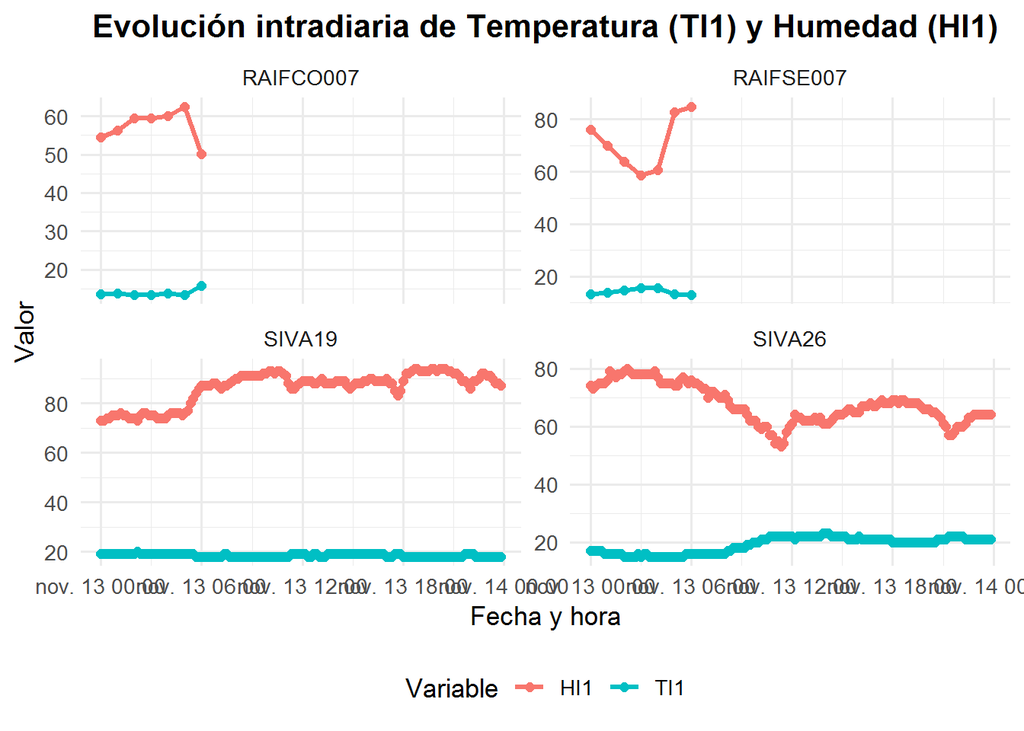

```r
# Selección de las cuatro primeras series y crear una columna de fecha-hora combinada
cestaciones_graph <- unique(datos_intradiarios1_alt$cestacion)[1:4]
datos_int <- datos_intradiarios1_alt %>%
  mutate(datetime = as.POSIXct(paste(fecha, hora), format = "%d/%m/%Y %H:%M")) %>%
  filter(cestacion %in% cestaciones_graph & cvariable %in% c("TI1", "HI1"))

# Crear el gráfico de temperaturas intradiarias por estación
ggplot(datos_int, aes(x = datetime, y = valor, color = cvariable, group = cvariable)) +
  geom_line(size = 1.2) +
  geom_point(size = 2) +
  facet_wrap(~ cestacion, scales = "free_y") +
  labs(
    title = "Evolución intradiaria de Temperatura (TI1) y Humedad (HI1)",
    x = "Fecha y hora",
    y = "Valor",
    color = "Variable"
  ) +
  theme_minimal(base_size = 13) +
  theme(
    plot.title = element_text(face = "bold", hjust = 0.5),
    legend.position = "bottom"
  )
```

# 📊 Visualización gráfica de datos diarios

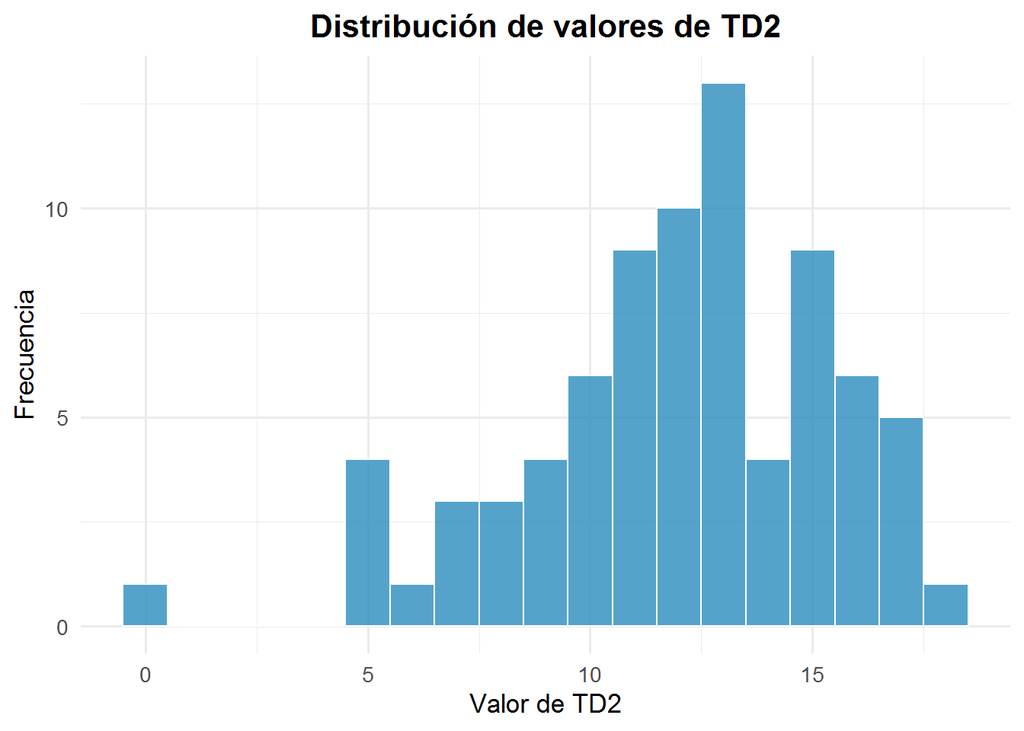

```r
# Selección de datos de TD2
datos_dia <- datos_diarios2_alt[datos_diarios2_alt$cvariable == 'TD2',]
# Histograma de frecuencias de datos de temperatura diaria
ggplot(datos_dia, aes(x = valor)) +
  geom_histogram(binwidth = 1, fill = "#2b8cbe", color = "white", alpha = 0.8) +
  labs(
    title = "Distribución de valores de TD2",
    x = "Valor de TD2",
    y = "Frecuencia"
  ) +
  theme_minimal(base_size = 13) +
  theme(
    plot.title = element_text(face = "bold", hjust = 0.5)
  )
```

# 💻 Autoría y contacto

Desarrollado por **mcorzot**. Repositorio oficial: https://github.com/mcorzot/climadiam